# Central Limit Theorem

Chad Worley

2024 Sep 20

# [Central limit theorem](https://en.wikipedia.org/wiki/Central_limit_theorem)

Let $X$ represent a [random variable](https://en.wikipedia.org/wiki/Random_variable) that generates [independent and identically distributed](https://en.wikipedia.org/wiki/Independent_and_identically_distributed_random_variables) numbers.

- You can visualize $X$ as a spinner.
- We can call $X$ the **population** that we sample from.

That random variable has an expected value (or population mean) and standard deviation.
$$\text{mean of
}X=\mu$$
$$\text{SD of
}X=\sigma$$

If we will average $n$ spins repeatedly, those averages will be **approximately normal** with the following parameters:
$$\text{mean
of normal approx}=\mu$$
$$\text{SD of
normal approx}=\frac{\sigma}{\sqrt{n}}$$

*This is true even if $X$ is NOT normally distributed. The approximation gets better with larger $n$.*

# Is the Central Limit Theorem important?

- Yes.
- Understanding the Central Limit Theorem is the most important step to unlocking the logic behind Statistics.
- Even if the population is not normal, averages (and totals) will be approximately normal.
- Remember how the normal (bell) curve kept showing up when we had averages of repetitions or sums of repetitions?

# Example: Dice

- Let random variable $X$ represent a fair 6-sided die.

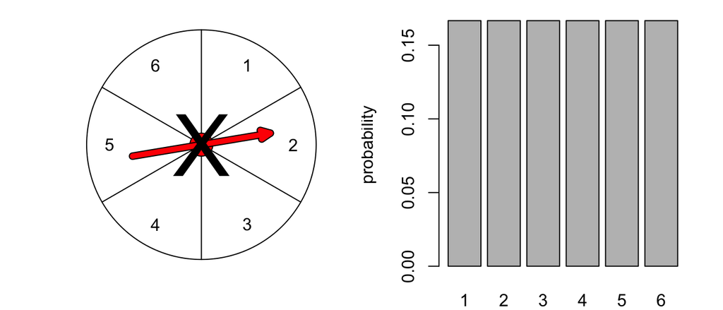

$$\mu = \frac{1+2+3+4+5+6}{6} =
3.5$$
$$\sigma =
\sqrt{\frac{(-2.5)^2+(-1.5)^2+(-0.5)^2+0.5^2+1.5^2+2.5^2}{6}} =
1.7078$$

# Example: Dice… (2d6)/2

- Let random variable $Y$ represent (2d6)/2, the average of 2 dice.
- There are 36 equally likely outcomes.

|  | 1 | 2 | 3 | 4 | 5 | 6 |
| --- | --- | --- | --- | --- | --- | --- |
| 1 | 1 | 1.5 | 2 | 2.5 | 3 | 3.5 |
| 2 | 1.5 | 2 | 2.5 | 3 | 3.5 | 4 |
| 3 | 2 | 2.5 | 3 | 3.5 | 4 | 4.5 |
| 4 | 2.5 | 3 | 3.5 | 4 | 4.5 | 5 |
| 5 | 3 | 3.5 | 4 | 4.5 | 5 | 5.5 |
| 6 | 3.5 | 4 | 4.5 | 5 | 5.5 | 6 |

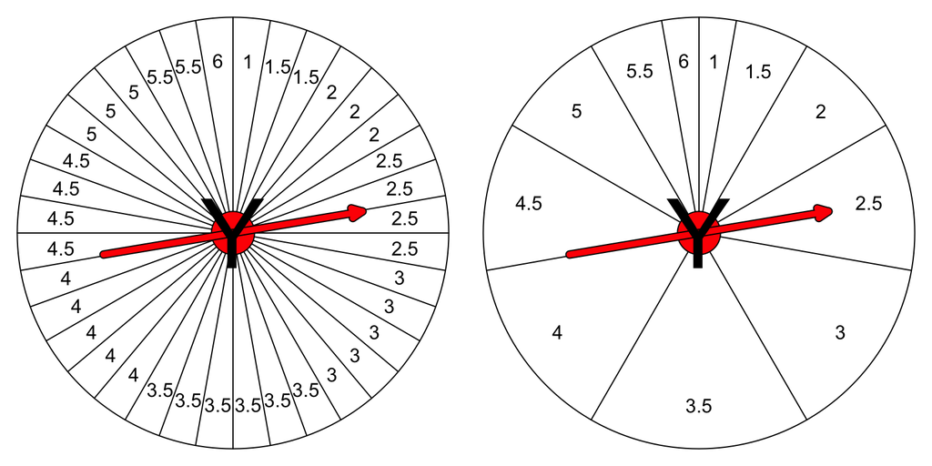

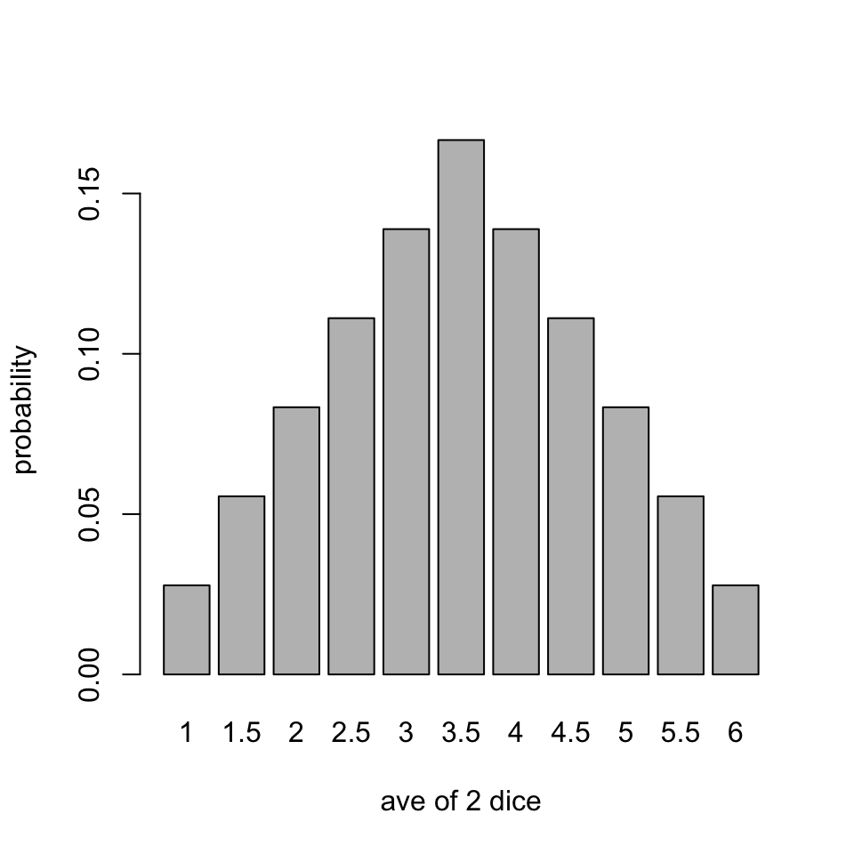

$$\mu = \frac{1\cdot 1 +1.5\cdot 2 +2\cdot
3 +2.5\cdot 4 +3\cdot 5 +3.5\cdot 6 +4\cdot 5 +4.5\cdot 4 +5\cdot 3
+5.5\cdot 2 +6\cdot 1}{36} = 3.5$$

- You can use the [standard deviation formula](https://en.wikipedia.org/wiki/Standard_deviation#Basic_examples) using all 36 possibilities to find $\sigma$.

$$\sigma = 1.2076$$

- We already learned [a shortcut](https://en.wikipedia.org/wiki/Algebra_of_random_variables#Variance_algebra_for_random_variables) to get $\sigma$ because we know the standard deviation of 1d6.

$$\frac{\sqrt{1.7078^2+1.7078^2}}{2} =
\frac{1.7078}{\sqrt{2}} = 1.2076$$

# Example: Dice… (3d6)/3

- What about the average of 3 dice?
- If we have 3 dice, there are $216$ equally likely possibilities:

111, 112, 113, 114, 115, 116, 121, 122, 123, 124, 125, 126, 131, 132, 133, 134, 135, 136, 141, 142, 143, 144, 145, 146, 151, 152, 153, 154, 155, 156, 161, 162, 163, 164, 165, 166, 211, 212, 213, 214, 215, 216, 221, 222, 223, 224, 225, 226, 231, 232, 233, 234, 235, 236, 241, 242, 243, 244, 245, 246, 251, 252, 253, 254, 255, 256, 261, 262, 263, 264, 265, 266, 311, 312, 313, 314, 315, 316, 321, 322, 323, 324, 325, 326, 331, 332, 333, 334, 335, 336, 341, 342, 343, 344, 345, 346, 351, 352, 353, 354, 355, 356, 361, 362, 363, 364, 365, 366, 411, 412, 413, 414, 415, 416, 421, 422, 423, 424, 425, 426, 431, 432, 433, 434, 435, 436, 441, 442, 443, 444, 445, 446, 451, 452, 453, 454, 455, 456, 461, 462, 463, 464, 465, 466, 511, 512, 513, 514, 515, 516, 521, 522, 523, 524, 525, 526, 531, 532, 533, 534, 535, 536, 541, 542, 543, 544, 545, 546, 551, 552, 553, 554, 555, 556, 561, 562, 563, 564, 565, 566, 611, 612, 613, 614, 615, 616, 621, 622, 623, 624, 625, 626, 631, 632, 633, 634, 635, 636, 641, 642, 643, 644, 645, 646, 651, 652, 653, 654, 655, 656, 661, 662, 663, 664, 665, 666

- We can find those averages.

1, 1.333, 1.667, 2, 2.333, 2.667, 1.333, 1.667, 2, 2.333, 2.667, 3, 1.667, 2, 2.333, 2.667, 3, 3.333, 2, 2.333, 2.667, 3, 3.333, 3.667, 2.333, 2.667, 3, 3.333, 3.667, 4, 2.667, 3, 3.333, 3.667, 4, 4.333, 1.333, 1.667, 2, 2.333, 2.667, 3, 1.667, 2, 2.333, 2.667, 3, 3.333, 2, 2.333, 2.667, 3, 3.333, 3.667, 2.333, 2.667, 3, 3.333, 3.667, 4, 2.667, 3, 3.333, 3.667, 4, 4.333, 3, 3.333, 3.667, 4, 4.333, 4.667, 1.667, 2, 2.333, 2.667, 3, 3.333, 2, 2.333, 2.667, 3, 3.333, 3.667, 2.333, 2.667, 3, 3.333, 3.667, 4, 2.667, 3, 3.333, 3.667, 4, 4.333, 3, 3.333, 3.667, 4, 4.333, 4.667, 3.333, 3.667, 4, 4.333, 4.667, 5, 2, 2.333, 2.667, 3, 3.333, 3.667, 2.333, 2.667, 3, 3.333, 3.667, 4, 2.667, 3, 3.333, 3.667, 4, 4.333, 3, 3.333, 3.667, 4, 4.333, 4.667, 3.333, 3.667, 4, 4.333, 4.667, 5, 3.667, 4, 4.333, 4.667, 5, 5.333, 2.333, 2.667, 3, 3.333, 3.667, 4, 2.667, 3, 3.333, 3.667, 4, 4.333, 3, 3.333, 3.667, 4, 4.333, 4.667, 3.333, 3.667, 4, 4.333, 4.667, 5, 3.667, 4, 4.333, 4.667, 5, 5.333, 4, 4.333, 4.667, 5, 5.333, 5.667, 2.667, 3, 3.333, 3.667, 4, 4.333, 3, 3.333, 3.667, 4, 4.333, 4.667, 3.333, 3.667, 4, 4.333, 4.667, 5, 3.667, 4, 4.333, 4.667, 5, 5.333, 4, 4.333, 4.667, 5, 5.333, 5.667, 4.333, 4.667, 5, 5.333, 5.667, 6

- We can count how many times each average shows up.

| average | count | probability | density |
| --- | --- | --- | --- |
| 1 | 1 | 0.005 | 0.015 |
| 1.333 | 3 | 0.014 | 0.042 |
| 1.667 | 6 | 0.028 | 0.084 |
| 2 | 10 | 0.046 | 0.138 |
| 2.333 | 15 | 0.069 | 0.207 |
| 2.667 | 21 | 0.097 | 0.291 |
| 3 | 25 | 0.116 | 0.348 |
| 3.333 | 27 | 0.125 | 0.375 |
| 3.667 | 27 | 0.125 | 0.375 |
| 4 | 25 | 0.116 | 0.348 |
| 4.333 | 21 | 0.097 | 0.291 |
| 4.667 | 15 | 0.069 | 0.207 |
| 5 | 10 | 0.046 | 0.138 |
| 5.333 | 6 | 0.028 | 0.084 |
| 5.667 | 3 | 0.014 | 0.042 |
| 6 | 1 | 0.005 | 0.015 |

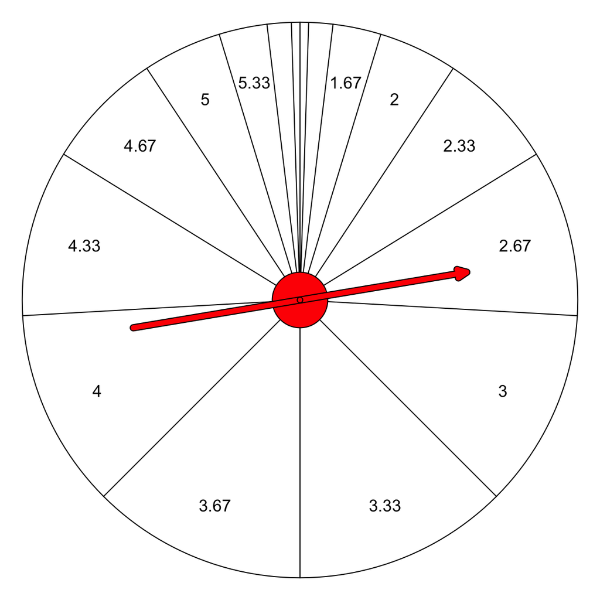

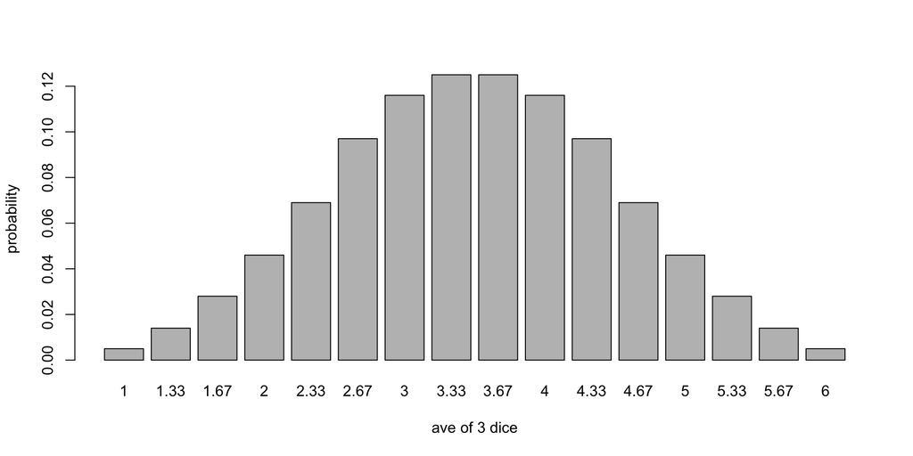

$$\mu = 3.5$$
$$\sigma = \frac{1.7078251}{\sqrt{3}} =
0.986$$

# Example Dice… cumulative average

- I rolled a die 25 times: 5, 6, 6, 1, 5, 1, 4, 5, 1, 2, 3, 1, 3, 6, 2, 3, 1, 6, 1, 4, 3, 6, 1, 6, 5
- As I went, I kept recalculating the average.

$$\bar{x}_1 = \frac{5}{1} = 5$$
$$\bar{x}_2 = \frac{5+6}{2} = 5.5$$
$$\bar{x}_3 = \frac{5+6+6}{3} =
5.6666667$$
$$\bar{x}_4 =
\frac{5+6+6+1}{4} = 4.5$$
$$\bar{x}_5
= \frac{5+6+6+1+5}{5} = 4.6$$
$$\bar{x}_6 = \frac{5+6+6+1+5+1}{6} =
4$$

- I plotted the average versus sample size. This is called a [cumulative average](https://en.wikipedia.org/wiki/Moving_average#Cumulative_average) curve or a running mean curve.

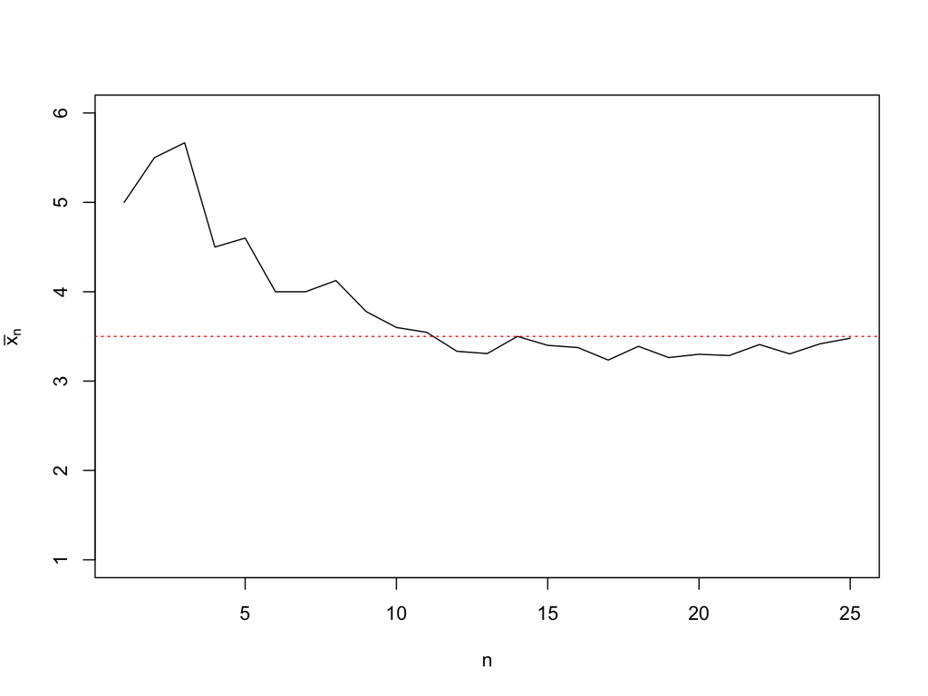

- Notice the cumulative average approaches $\mu=3.5$ as $n$ increases. This is a representation of the [law of large numbers](https://en.wikipedia.org/wiki/Law_of_large_numbers).

# Example Dice… overlapping cumulative-average curves

- This time I rolled 100 dice to make a cumulative-average curve. Then I repeated that process 1000 times. I plotted those 1000 cumulative-average curves.

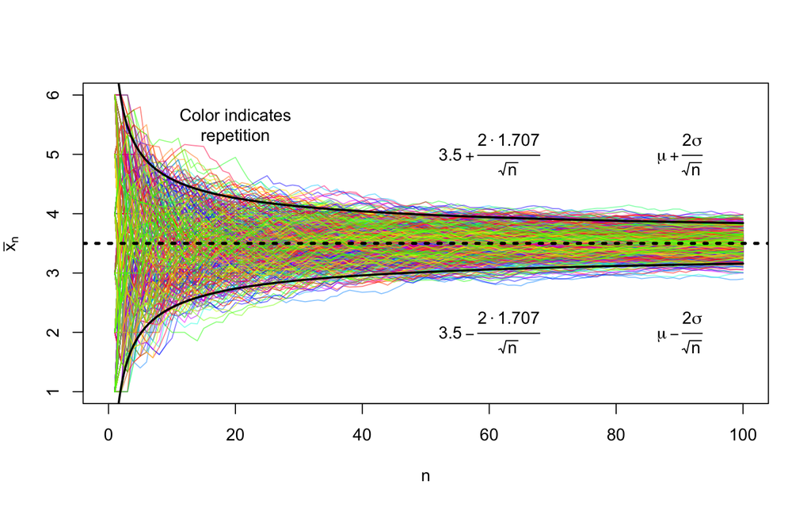

- For each value of $n$, we can make a histogram of the 1000 current averages.

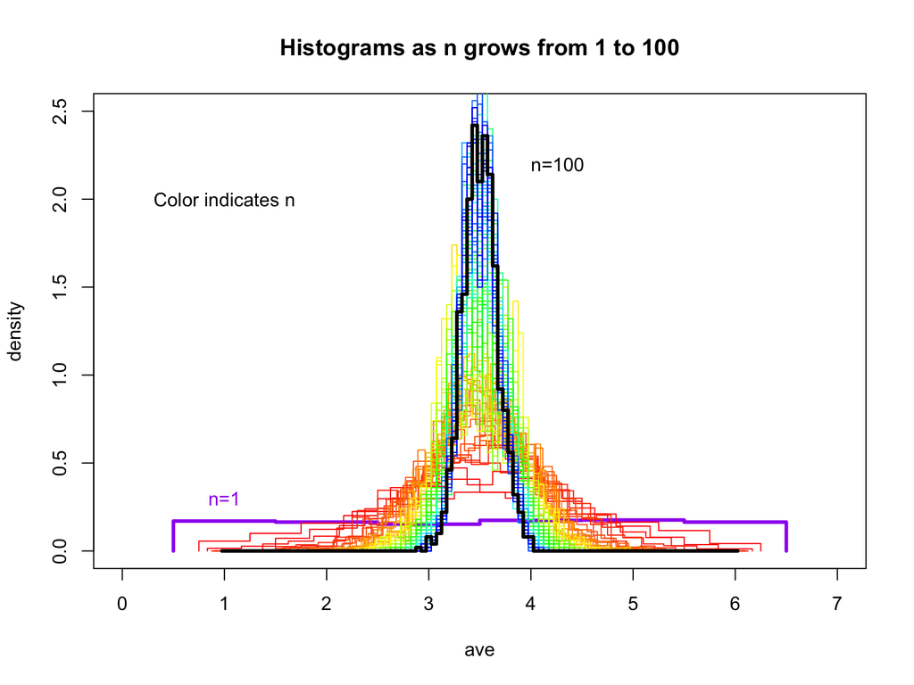

- We could have predicted this shape based on probabilities.

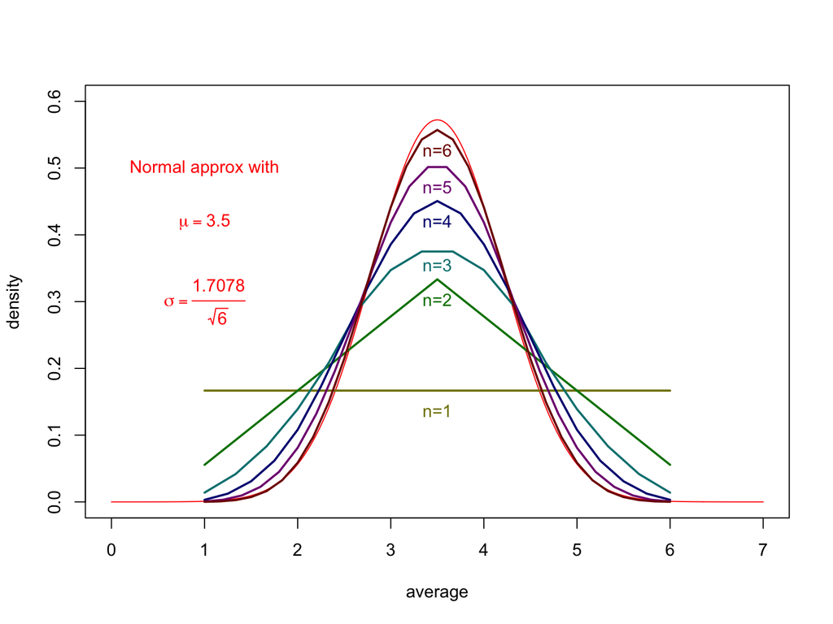

- Notice the normal approximation is quite close. It gets better as $n$ increases.
- This animation might help.

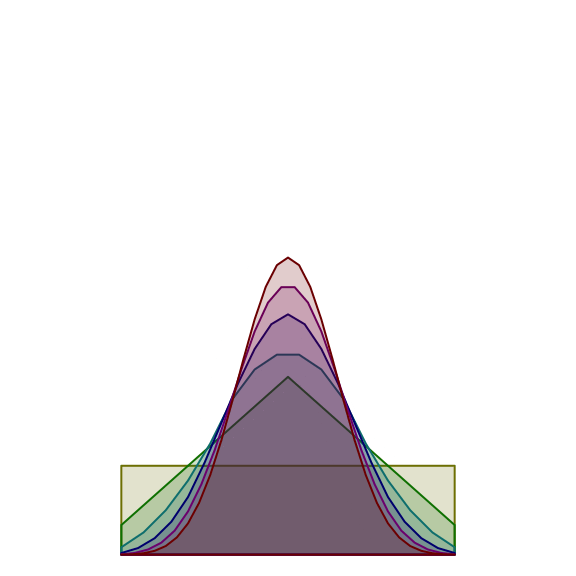

# NOT JUST DICE!

- But the central limit theorem is not just about dice.
- We can start with just about any spinner, and once $n>20$, the averages will be approximately normal.
- You can even see the progression toward a normal (bell-shaped) curve when $n$ is small.
- Fair coin

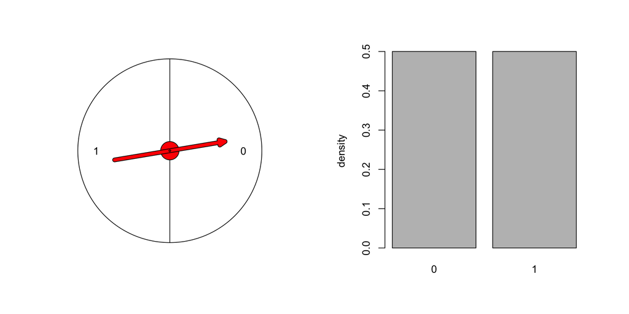

- Average of two fair coins

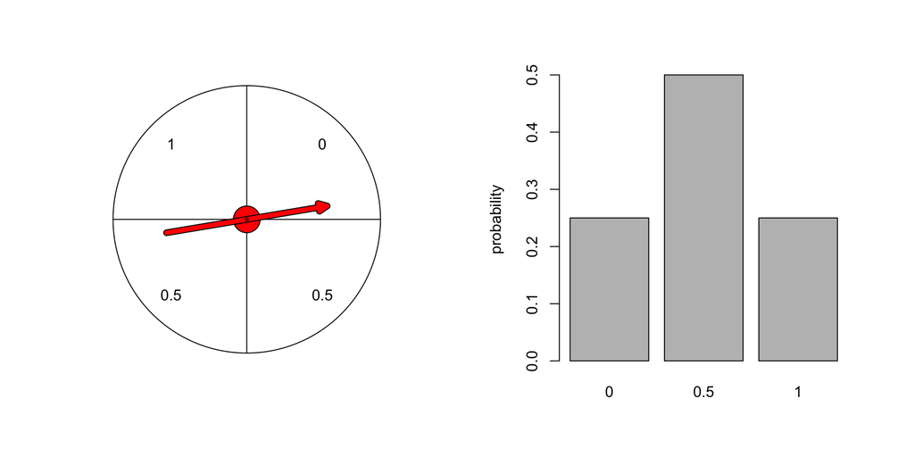

- Average of 3 fair coins (proportion heads after 3 flips)

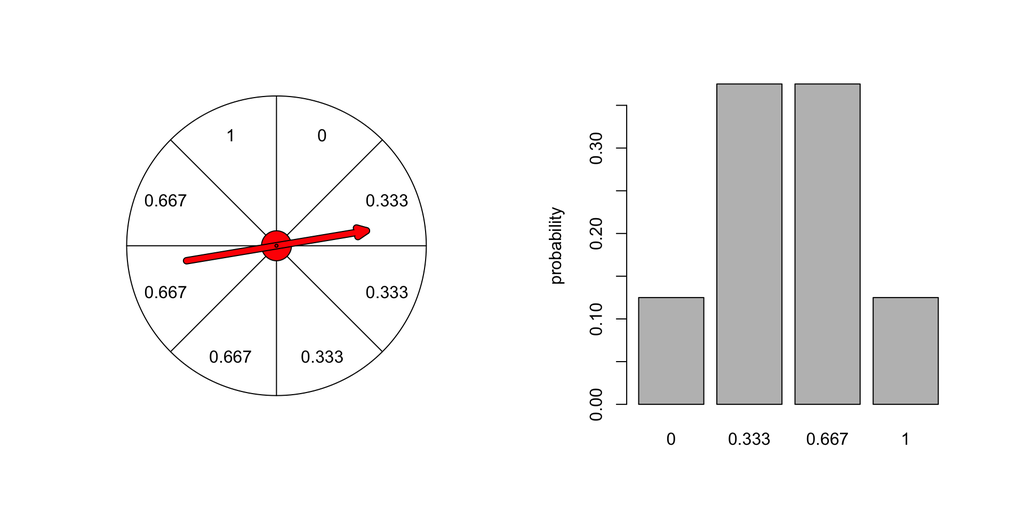

- Average of 4 fair coins (proportion of heads after 4 flips)

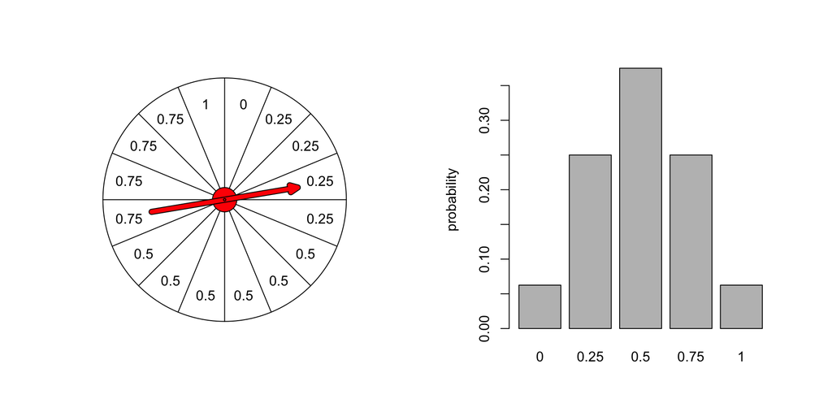

# Not just dice and coins

- Try out these random-number generators to explore the central limit theorem:
- https://chadworley.github.io/a2/tools/running_ave.html
  - Set the values to `11,12,15,19`.
  - Set the weights to `10,2,6,6`.
  - Click `Update`.
  - Generate a bunch of samples.
  - Notice the running averages follow the predicted funnel shape.
  - Adjust the settings and repeat.
- [https://chadworley.github.io/a2/tools/cltsim.html](https://chadworley.github.io/a2/tools/cltsim.html?poss=1*6*8&wght=0.2*0.2*0.6&numrs=1000&numcs=100)
  - Click `Get Sample`.
  - Click `Copy to Clipboard`.
  - Paste into a spreadsheet.
  - Make histogram of the column labelled `ave`.
  - Notice it is bell shaped.
  - Get `STDEV` of column `ave`. Notice it is approximately $\frac{\sigma}{\sqrt{n}}$.
  - Adjust the settings and repeat.

# What?

- Normal distributions keep showing up!
- We are going to focus on normal distributions for a while.

# So what is a [normal distribution](https://en.wikipedia.org/wiki/Normal_distribution)?

The [density curve](https://en.wikipedia.org/wiki/Probability_density_function) of a normal distribution is defined for mean $\mu$ and standard deviation $\sigma$:

$$\mathrm{normal\_density(x)} =
\frac{1}{\sigma\sqrt{2\pi}}e^{-(x-\mu)^2/(2\sigma^2)}$$

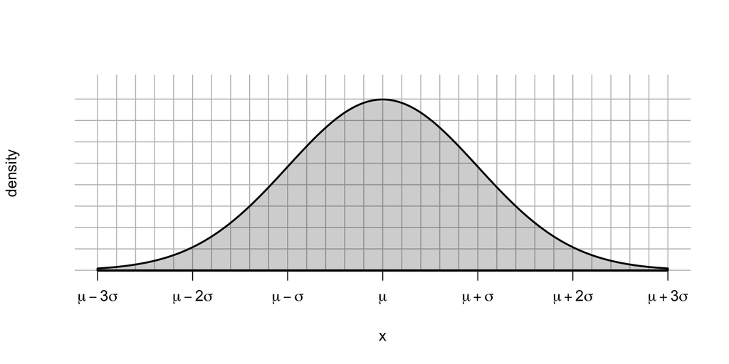

# Finding normal probabilities

- To find a normal probability, you need to find an area under the normal density curve. I’ve shown some commonly known areas below:

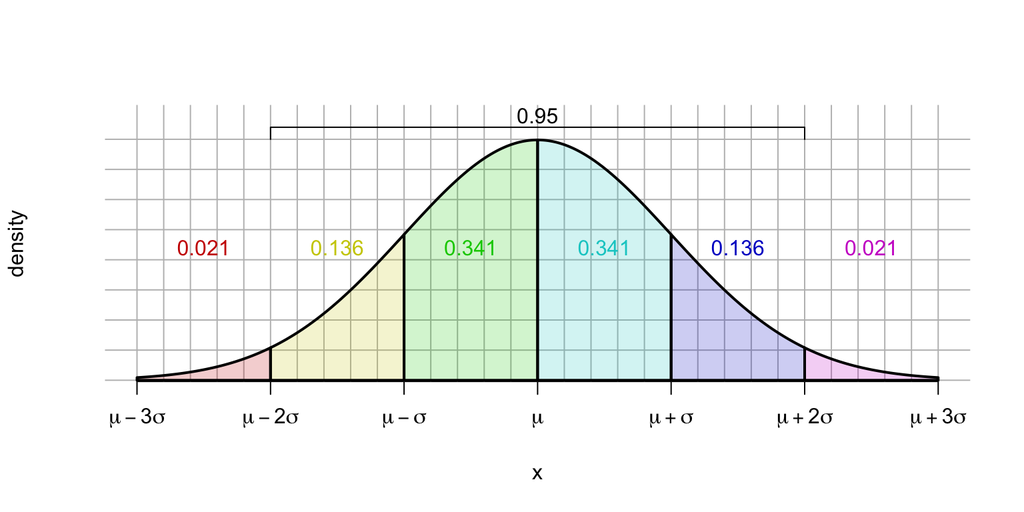

- For example, let random variable $X$ be normally distributed with $\mu=100$ and $\sigma=10$.
- To find the probability that $X$ is between 90 and 120, we find the area between 90 and 120.

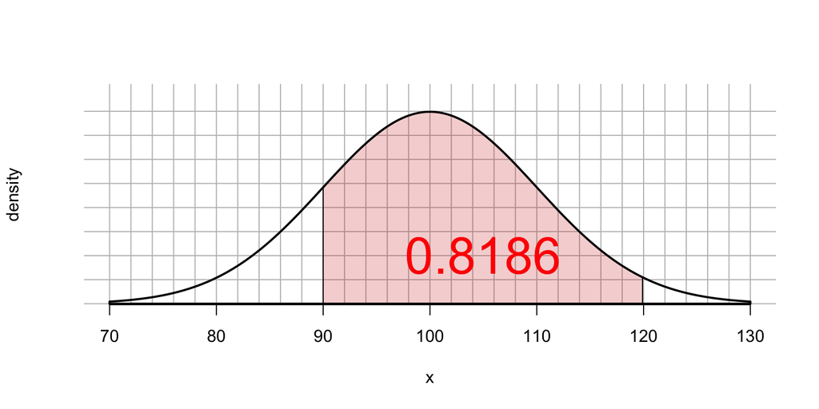

$$P(90<X<120) = 0.8186$$

# Tools for finding normal probabilities

- In a spreadsheet with `=NORM.DIST`
- My [online tool](https://chadworley.github.io/a2/tools/normal.html).
- [Desmos](https://www.desmos.com/calculator) with expression `NORMALDIST()` and `Find Cumulative Probability`.
- This [z table](https://chadworley.github.io/a2/u03/ztable.pdf)
- A [more confusing z table](https://www.sjsu.edu/faculty/gerstman/EpiInfo/z-table.htm)
- A [spreadsheet z table](https://docs.google.com/spreadsheets/d/1xwo7YjjCoEiWfFeSfkuo10kGwofiAznZ9T-5yKGQfdg/edit?usp=sharing)